# Replicating “What is the best measure of labor market tightness?”

Itamar Caspi

2021-11-24

Abstract

This notebook includes replication of some of the regression results that appear in [“What is the best measure of labor market tightness?”](https://www.piie.com/blogs/realtime-economic-issues-watch/what-best-measure-labor-market-tightness) by [Jason Furman](https://www.piie.com/experts/senior-research-staff/jason-furman) and [Willson Powell III](https://www.piie.com/experts/former-research-staff/wilson-powell-iii).

## Load packages

```r
library(tidyverse)   # for data wrangling and plots
library(lubridate)   # for dealing with dates
library(fredr)       # a FRED api
library(broom)       # tidying regression output
library(hrbrthemes)  # fancy plots
library(gghighlight) # for labeling series in plots
library(gt)          # fancy tables
```

## Download data from [FRED](https://fred.stlouisfed.org/)

Note: To run this code, you’ll first need to get a [FRED API key](https://fred.stlouisfed.org/docs/api/api_key.html) and then set it using the `fredr_set_key()` function.

Download data

```r
params <- list(
  series_id = c(
    "PAYEMS", "UNRATE", "LNS12300060", "JTSQUL", "JTSJOL", "UNEMPLOY", "CPILFESL", "PCEPILFE"
    ),
  frequency = c("q", "q", "q", "q", "q", "q", "q", "q"),
  units = c("lin", "lin", "lin", "lin", "lin", "lin", "pc1", "pc1")
)

df_raw <- pmap_dfr(
  .l = params,
  .f = ~ fredr(series_id = ..1, frequency = ..2, units = ..3)
)
```

## Preprocess data

Change to “wide” format

```r
df_wide <-
  df_raw %>%
  select(date, series_id, value) %>%
  pivot_wider(names_from = "series_id", values_from = "value")

head(df_wide)
```

```
## # A tibble: 6 x 9
##   date       PAYEMS UNRATE LNS12300060 JTSQUL JTSJOL UNEMPLOY CPILFESL PCEPILFE
##   <date>      <dbl>  <dbl>       <dbl>  <dbl>  <dbl>    <dbl>    <dbl>    <dbl>
## 1 1939-01-01  30101     NA          NA     NA     NA       NA       NA       NA
## 2 1939-04-01  30298     NA          NA     NA     NA       NA       NA       NA
## 3 1939-07-01  30704     NA          NA     NA     NA       NA       NA       NA
## 4 1939-10-01  31474     NA          NA     NA     NA       NA       NA       NA
## 5 1940-01-01  31714     NA          NA     NA     NA       NA       NA       NA
## 6 1940-04-01  31852     NA          NA     NA     NA       NA       NA       NA
```

Calculate and rename variables

```r
df <-
  df_wide %>%
  mutate(
    ur       = UNRATE,
    panr     = 100 - LNS12300060,
    upjo     = UNEMPLOY / JTSJOL,
    qr       = 100 - 100 * JTSQUL/PAYEMS,
    core_cpi = CPILFESL,
    core_pce = PCEPILFE
  ) %>%
  select(date, ur, panr, upjo, qr, core_cpi, core_pce) %>%
  filter(between(date, ymd("2001-01-01"), ymd("2021-07-31")))

head(df)
```

```
## # A tibble: 6 x 7
##   date          ur  panr  upjo    qr core_cpi core_pce
##   <date>     <dbl> <dbl> <dbl> <dbl>    <dbl>    <dbl>
## 1 2001-01-01   4.2  18.7  1.21  97.7     2.65     1.99
## 2 2001-04-01   4.4  19.2  1.42  97.7     2.64     2.02
## 3 2001-07-01   4.8  19.7  1.66  97.8     2.66     1.79
## 4 2001-10-01   5.5  20.2  2.15  98.0     2.71     1.78
## 5 2002-01-01   5.7  20.3  2.30  98.0     2.53     1.43
## 6 2002-04-01   5.8  20.6  2.46  98.0     2.43     1.61
```

Transformer variables to Z-scores based on a mean and standard deviation from 2001 to 2018.

First, get mean and standard deviation

```r
params <-
  df %>%
  filter(date <= ymd("2018-12-31")) %>%
  summarise(across(ur:core_pce, list(mean = mean, sd = sd)))

params
```

```
## # A tibble: 1 x 12
##   ur_mean ur_sd panr_mean panr_sd upjo_mean upjo_sd qr_mean qr_sd core_cpi_mean
##     <dbl> <dbl>     <dbl>   <dbl>     <dbl>   <dbl>   <dbl> <dbl>         <dbl>
## 1    6.10  1.77      22.0    1.80      2.45    1.33    98.1 0.285          1.97
## # ... with 3 more variables: core_cpi_sd <dbl>, core_pce_mean <dbl>,
## #   core_pce_sd <dbl>
```

```r
# generate z-scores
df_zscore <-
  df %>%
  mutate(
    ur       = (ur - params$ur_mean) / params$ur_sd,
    panr     = (panr - params$panr_mean) / params$panr_sd,
    upjo     = (upjo - params$upjo_mean) / params$upjo_sd,
    qr       = (qr - params$qr_mean) / params$qr_sd,
    core_cpi = (core_cpi - params$core_cpi_mean) / params$core_cpi_sd,
    core_pce = (core_pce - params$core_pce_mean) / params$core_pce_sd
  )

head(df_zscore)
```

```
## # A tibble: 6 x 7
##   date           ur   panr     upjo     qr core_cpi core_pce
##   <date>      <dbl>  <dbl>    <dbl>  <dbl>    <dbl>    <dbl>
## 1 2001-01-01 -1.08  -1.85  -0.931   -1.63      1.52   0.629
## 2 2001-04-01 -0.962 -1.58  -0.775   -1.37      1.49   0.704
## 3 2001-07-01 -0.736 -1.30  -0.595   -0.994     1.53   0.121
## 4 2001-10-01 -0.340 -1.02  -0.225   -0.450     1.66   0.0854
## 5 2002-01-01 -0.227 -0.964 -0.110   -0.470     1.25  -0.806
## 6 2002-04-01 -0.170 -0.797  0.00788 -0.273     1.01  -0.356
```

## Plot time series

Labor market indicators

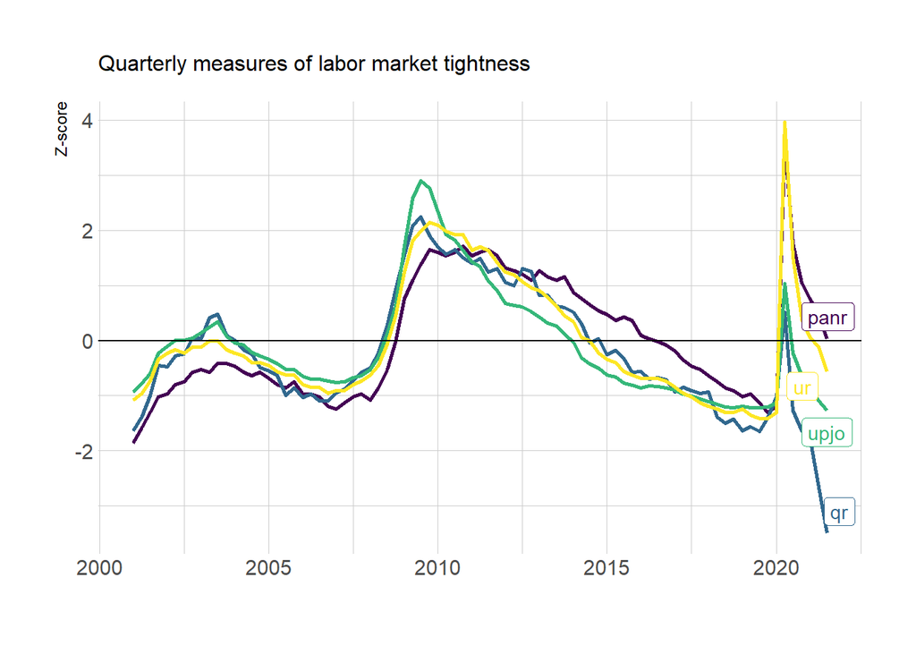

```r
df_zscore %>%
  select(-starts_with("core")) %>%
  pivot_longer(-date, names_to = "name", values_to = "value") %>%
  ggplot(aes(date, value, color = name)) +
  geom_line(size = 1) +
  scale_color_viridis_d() +
  gghighlight(max(value) > -999) +
  geom_hline(aes(yintercept = 0)) +
  theme_ipsum() +
  labs(
    subtitle = "Quarterly measures of labor market tightness",
    x = "",
    y = "Z-score"
  )
```

Inflation indicators

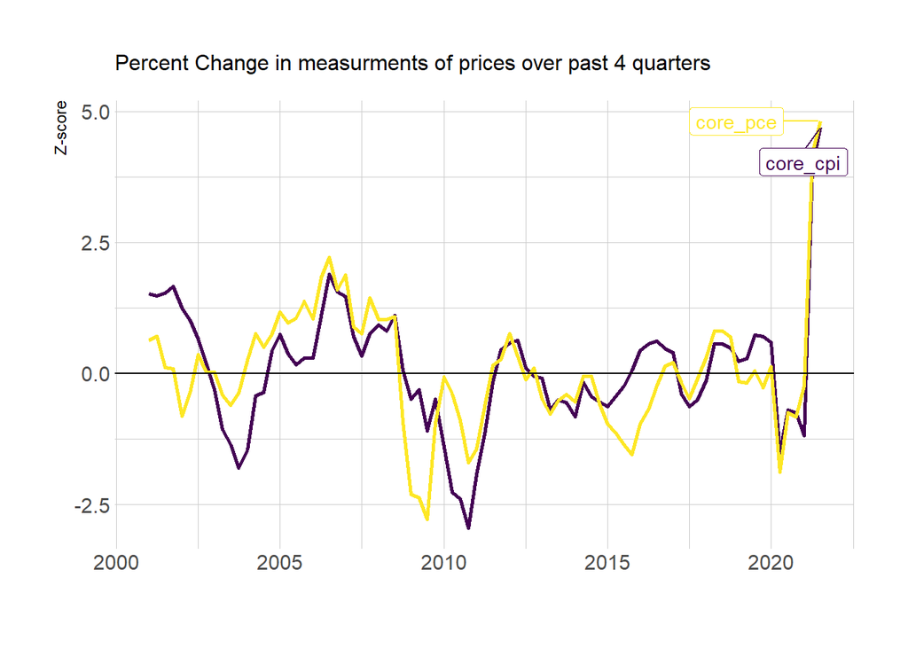

```r
df_zscore %>%
  select(date, starts_with("core")) %>%
  pivot_longer(-date, names_to = "name", values_to = "value") %>%
  ggplot(aes(date, value, color = name)) +
  geom_line(size = 1) +
  scale_color_viridis_d() +
  gghighlight(max(value) > -999) +
  geom_hline(aes(yintercept = 0)) +
  theme_ipsum() +
  labs(
    subtitle = "Percent Change in measurments of prices over past 4 quarters",
    x = "",
    y = "Z-score"
  )
```

## Regression analysis

We now estimate a traditional and an autoregressive Phillips curve that relates current measures of slack to changes in prices over the next year:

$$\text { Inflation growth }_{\mathrm{t} \text { to } \mathrm{t}+4 \mathrm{q}}=\beta_{0}+\beta_{1} * \text { Slack }_{t}+\varepsilon_t$$
and
$$\text { Inflation growth }_{\mathrm{t} \text { to } \mathrm{t}+4 \mathrm{q}}=\beta_{0}+\beta_{1} * \text { Slack }_{t}+\text { Inflation growth }_{\mathrm{t}-4\mathrm{q}\text { to } \mathrm{t}}\varepsilon_t$$

First, nest the data to make easier to “map” over the different models

```r
df_nest <-
  df_zscore %>%
  filter(date <= ymd("2019-12-31")) %>%
  pivot_longer(-c(date, core_cpi, core_pce) ,names_to = "name", values_to = "value") %>%
  group_by(name) %>%
  nest()

head(df_nest)
```

```
## # A tibble: 4 x 2
## # Groups:   name [4]
##   name  data
##   <chr> <list>
## 1 ur    <tibble [76 x 4]>
## 2 panr  <tibble [76 x 4]>
## 3 upjo  <tibble [76 x 4]>
## 4 qr    <tibble [76 x 4]>
```

Next, run the regressions and store the results

```r
df_results <-
  df_nest %>%
  mutate(
    model_cpi    = map(data, ~ lm(core_cpi ~ lag(value, 4), data = .)),
    model_pce    = map(data, ~ lm(core_pce ~ lag(value, 4), data = .)),
    model_cpi_ar = map(data, ~ lm(core_cpi ~ lag(value, 4) + lag(core_cpi, 4), data = .)),
    model_pce_ar = map(data, ~ lm(core_pce ~ lag(value, 4) + lag(core_pce, 4), data = .)),
    stats_cpi    = map(model_cpi, ~ glance(.)),
    stats_pce    = map(model_pce, ~ glance(.)),
    stats_cpi_ar = map(model_cpi_ar, ~ glance(.)),
    stats_pce_ar = map(model_pce_ar, ~ glance(.))
  ) %>%
  unnest(stats_cpi, stats_pce, stats_cpi_ar, stats_pce_ar) %>%
  select(name, adj.r.squared, adj.r.squared1, adj.r.squared2, adj.r.squared3)
```

## Results

Print results with the help of the [`gt`](https://gt.rstudio.com/) package

```r
df_results %>%
  ungroup() %>%
  gt() %>%
  tab_header(
    title = "Adjusted R squared from Phillips cureve regressions"
  ) %>%
  cols_label(
    name           = "Dependent var.",
    adj.r.squared  = "Core CPI",
    adj.r.squared1 = "Core PCE",
    adj.r.squared2 = "Core CPI",
    adj.r.squared3 = "Core PCE"
  ) %>%
  tab_spanner(
    label = "Traditional",
    columns = c(adj.r.squared, adj.r.squared1)
  ) %>%
  tab_spanner(
    label = "Autoregressive",
    columns = c(adj.r.squared2, adj.r.squared3)
  ) %>%
  fmt_number(
    columns = starts_with("adj."),
    decimals = 2
  )
```

Adjusted R squared from Phillips cureve regressions

| Dependent var. | Traditional Core CPI | Traditional Core PCE | Autoregressive Core CPI | Autoregressive Core PCE |
| --- | --- | --- | --- | --- |
| ur | 0.33 | 0.07 | 0.35 | 0.07 |
| panr | 0.22 | 0.09 | 0.22 | 0.08 |
| upjo | 0.42 | 0.05 | 0.45 | 0.05 |
| qr | 0.41 | 0.10 | 0.47 | 0.09 |

For more results and further details, please refer to the [full article](https://www.piie.com/blogs/realtime-economic-issues-watch/what-best-measure-labor-market-tightness).